# Analyse des données avec R

08 janvier, 2022

## Tester un effet

## Principes généraux

**Y-a-t’il un effet de ceci sur cela ?**

Effet de ceci sur cela : lien entre ceci et cela à l’échelle d’une population

**Exemples** :

- Les poids moyens sont-ils les mêmes pour toutes les variétés ?
- Le diamètre dépend-il de l’indice de clarté *L* ?
- Peut-on prédire la maturité par les indices de colorimétrie ?

- **la population visée ?**
- **ceci (variable explicative) ?**
- **cela (variable à expliquer) ?**

## Effet groupe

## Exemple

**Les poids moyens des fruits par variété sont-il différents ?**

```r
tab <- fruit %>% group_by(Variete) %>% summarise(Mean=mean(Poids))
tab %>% mutate(Mean=round(Mean,digits=2)) %>% t() %>%
  kbl(caption="Résumé statistique de Poids") %>%
  kable_paper(bootstrap_options = "striped", full_width = F)
```

Résumé statistique de Poids

| Variete | A | B | C | D |
| --- | --- | --- | --- | --- |
| Mean | 56.0 | 61.6 | 70.7 | 53.2 |

Les poids moyens par variété **sont différents**.

Le sont-ils **suffisamment** pour conclure que les différences entre variétés existent à l’échelle de toute la production ?

## Modèle d’analyse de la variance à un facteur

**Ajustement du modèle :**

```r
mod1 <- lm(Poids~Variete,data=fruit)
coef(mod1)
```

```
(Intercept)    VarieteB    VarieteC    VarieteD
      55.99        5.63       14.68       -2.83
```

**Quelle est la variété pour laquelle les fruits sont les plus lourds ?**

## Modèle nul

Sous l’hypothèse d’**absence effet** (modèle nul)

```r
mod0 <- lm(Poids~1,data=fruit)
coef(mod0)
```

```
(Intercept)
       60.6
```

**Pourquoi l’estimation de ‘(Intercept)’ n’est pas la même avec les modèles nul et alternatif ?**

## Evaluation de l’effet groupe ; rapport signal/bruit

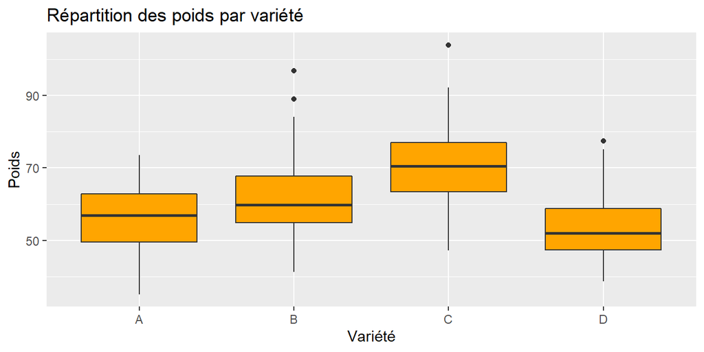

```r
fruit %>% ggplot() + geom_boxplot(aes(x=Variete,y=Poids),fill="orange") +
  ggtitle("Répartition des poids par variété") + xlab("Variété") + ylab("Poids")
```

## Test de Fisher

**Comparaison des modeles nul et alternatif**

```r
anova(mod0,mod1) %>% kbl(caption="Effet Variété sur le poids") %>%
  kable_paper(bootstrap_options = "striped", full_width = F)
```

Effet Variété sur le poids

| Res.Df | RSS | Df | Sum of Sq | F | Pr(>F) |
| --- | --- | --- | --- | --- | --- |
| 434 | 59075 |  |  |  |  |
| 431 | 38763 | 3 | 20312 | 75.3 | 0 |

**Conclusion** : les poids moyens par variété sont significativement différents au seuil de 5%,

[figure not shown]

: Les poids moyens par variété ne sont peut-être pas **tous** mutuellement significativement différents.

## Focus sur la comparaison de deux moyennes

**Les poids moyens des fruits de variétés A et B sont-ils significativement différents ?**

**Alternative : test de Student**

- Test de référence pour des hypothèses nulles du type *un paramètre est égal à une valeur cible*
- Ici, l’hypothèse nulle est : *la différence entre les poids moyens des fruits de variétés A et B est égale à 0*

## Test de Student

```r
fruit2 <- fruit %>% filter(Variete%in%c("A","B")) %>% droplevels()
t.test(Poids~Variete,data=fruit2,var.equal=TRUE)
```

```
    Two Sample t-test

data:  Poids by Variete
t = -4, df = 207, p-value = 7e-05
alternative hypothesis: true difference in means is not equal to 0
95 percent confidence interval:
 -8.37 -2.90
sample estimates:
mean in group A mean in group B
           56.0            61.6
```

## Puissance du dispositif experimental

Si les poids moyens des fruits de variétés A et B diffèrent de \(\delta=2\) grammes, le test détecte-t’il cette différence ?

```r
mod = lm(Poids~Variete,data=fruit2)
sigma = summary(mod)$sigma
power.t.test(delta=2,n=100,sd=sigma,sig.level=0.05)$power
```

```
[1] 0.289
```

**Combien de fruits sont nécessaires pour qu’une différence de 2g soit détectable ?**

## Comparaisons par paires

```r
comp <- emmeans(mod1, ~ Variete)
pairs(comp,adjust="bonf") %>% kbl(caption="Comparaisons par paires") %>%
  kable_paper(bootstrap_options = "striped", full_width = F)
```

Comparaisons par paires

| contrast | estimate | SE | df | t.ratio | p.value |
| --- | --- | --- | --- | --- | --- |
| A - B | -5.63 | 1.31 | 431 | -4.29 | 0.000 |
| A - C | -14.68 | 1.27 | 431 | -11.59 | 0.000 |
| A - D | 2.83 | 1.29 | 431 | 2.18 | 0.177 |
| B - C | -9.04 | 1.28 | 431 | -7.05 | 0.000 |
| B - D | 8.46 | 1.31 | 431 | 6.46 | 0.000 |
| C - D | 17.50 | 1.26 | 431 | 13.86 | 0.000 |

**Les indices ‘a’ moyens par stade de maturité sont-ils différents ?**

## Effet linéaire

## Exemple

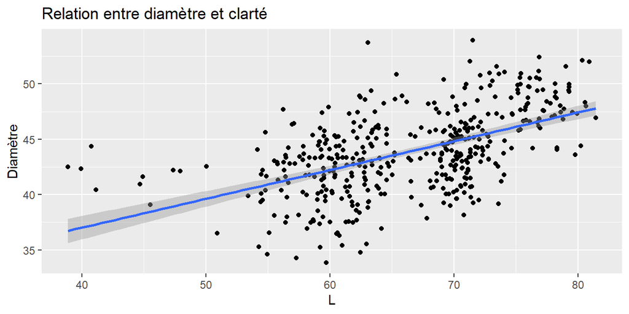

```r
fruit %>% ggplot() + aes(x=L,y=Diam) +
  geom_point() + geom_smooth(method='lm') +
  ggtitle("Relation entre diamètre et clarté") + xlab("L") + ylab("Diamètre")
```

## Corrélation

Le *coefficient de corrélation* \(-1 \leq r \leq 1\) mesure l’intensité du lien linéaire entre deux variables :

```r
cor(fruit$L,fruit$Diam)
```

```
[1] 0.535
```

Interprétation (à confirmer par graphique) :

- Si \(r \approx 1\) : relation linéaire croissante très forte
- Si \(r \approx -1\) : relation linéaire décroissante très forte
- Si \(r \approx 0\) : absence de lien linéaire

La relation linéaire entre clarté et diamètre est-elle significative ?

## Modèle de régression linéaire

**Estimation de la droite de régression**

```r
mod1 <- lm(Diam~L,data=fruit)
coef(mod1)
```

```
(Intercept)           L
      26.61        0.26
```

**Valeurs ajustées de la variable à expliquer**

```r
fruit$Diam_fit <- fitted(mod1)
fruit %>% slice(n=1) %>% kbl() %>% kable_paper(bootstrap_options = "striped")
```

|  | Poids | Diam | L | a | b | Variete | Maturite | Diam_fit |
| --- | --- | --- | --- | --- | --- | --- | --- | --- |
| 371p05 | 48 | 36.9 | 64.2 | -6.78 | 42.4 | A | Faible | 43.3 |

## Evaluation (graphique) de l’ajustement

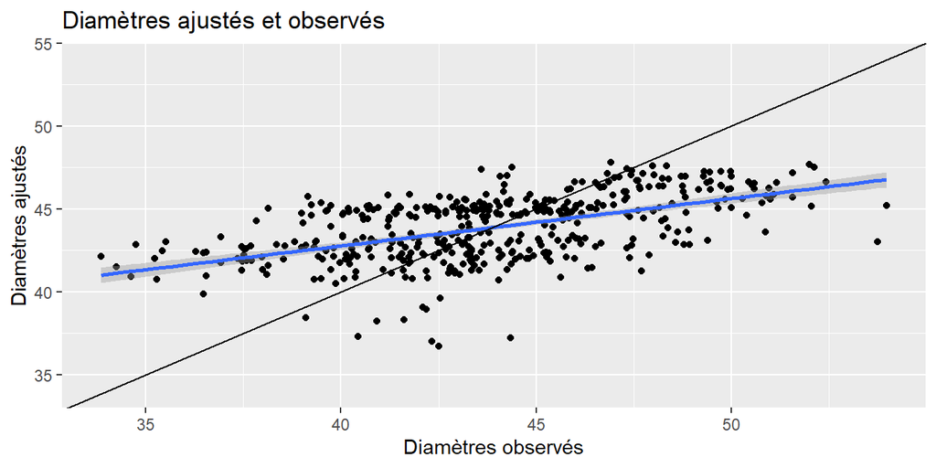

```r
fruit %>% ggplot(aes(x=Diam,y=Diam_fit)) + geom_point() + geom_smooth(method='lm') +
  ggtitle("Diamètres ajustés et observés") + geom_abline(intercept=0,slope=1) +
  xlab("Diamètres observés") + ylab("Diamètres ajustés") + ylim(34,54)
```

## Evaluation (numérique) de l’ajustement

\(\mathbf{R}^{2}\) : deux interprétations

```r
summary(mod1)$r.squared
```

```
[1] 0.286
```

```r
cor(fruit$Diam,fruit$Diam_fit)^2
```

```
[1] 0.286
```

```r
var(fruit$Diam_fit)/var(fruit$Diam)
```

```
[1] 0.286
```

## Test de Fisher

**Comparaison des modèles nul et alternatif**

```r
mod0 <- lm(Diam~1,data=fruit)
anova(mod0,mod1) %>% kbl(caption="Lien entre Clarté et Diamètre") %>%
  kable_paper(bootstrap_options = "striped", full_width = F)
```

Lien entre Clarté et Diamètre

| Res.Df | RSS | Df | Sum of Sq | F | Pr(>F) |
| --- | --- | --- | --- | --- | --- |
| 434 | 5988 |  |  |  |  |
| 433 | 4273 | 1 | 1714 | 174 | 0 |

**Conclusion** : la relation linéaire entre **diamètre** et **clarté** est significative au seuil de 5%,

## Prédiction

**Intervalle de confiance (95%) d’ajustement**

```r
new_fruit <- data.frame(L=c(40,60))
predict(mod1,newdata=new_fruit,interval="confidence")
```

```
   fit  lwr  upr
1 37.0 36.0 38.1
2 42.2 41.8 42.6
```

**Intervalle de confiance (95%) de prédiction**

```r
predict(mod1,newdata=new_fruit,interval="prediction")
```

```
   fit  lwr  upr
1 37.0 30.8 43.3
2 42.2 36.0 48.4
```

## Effet linéaire par groupes

```r
mod2 <- lm(Diam~L*Variete,data=fruit)
coef(mod2)
```

```
(Intercept)           L    VarieteB    VarieteC
    41.1686     -0.0130    -26.8698     -5.8875
   VarieteD  L:VarieteB  L:VarieteC  L:VarieteD
     0.7273      0.5015      0.1794      0.0308
```

**Quelle est l’équation permettant de prédire Diam par L pour la variété A ? et pour la variété B ?**

## Equation unique ou équations par groupe ?

**Test de Fisher**

```r
anova(mod1,mod2) %>% kbl() %>%
  kable_paper(bootstrap_options = "striped", full_width = F)
```

| Res.Df | RSS | Df | Sum of Sq | F | Pr(>F) |
| --- | --- | --- | --- | --- | --- |
| 433 | 4273 |  |  |  |  |
| 427 | 2717 | 6 | 1556 | 40.8 | 0 |

## Caractérisation de groupes

## Modèle pour variable catégorielle

**La maturité dépend-elle de la clarté ?**

```r
mod = lm(Maturite~L,data=fruit)
```

```
Warning in model.response(mf, "numeric"): using
type = "numeric" with a factor response will be
ignored
```

```
Warning in Ops.ordered(y, z$residuals): '-' is not
meaningful for ordered factors
```

```r
coef(mod)
```

```
(Intercept)           L
    1.68129     0.00401
```

## Modèle de régression logistique multinomiale

**Modèle de régression pour variable catégorielle**

```r
mod = multinom(Maturite~L,data=fruit,trace=FALSE)
coef(mod)
```

```
        (Intercept)        L
Moyenne       0.244 -0.00319
Forte        -1.053  0.01334
```

## Probabilités d’appartenance à un groupe (1/2)

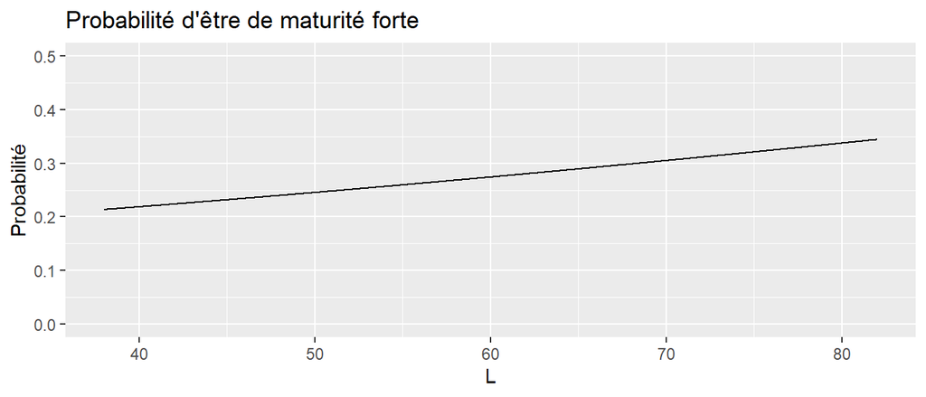

```r
seq_L <- seq(from=38,to=82,length=1000)
probas <- predict(mod,newdata=data.frame(L=seq_L),type="probs")
probas <- bind_cols(probas,L=seq_L)
probas %>% ggplot(aes(x=L,y=Forte)) + ylim(0,0.5) + geom_line() + xlab("L") +
  ggtitle("Probabilité d'être de maturité forte") + ylab("Probabilité")
```

## Probabilités d’appartenance à un groupe (2/2)

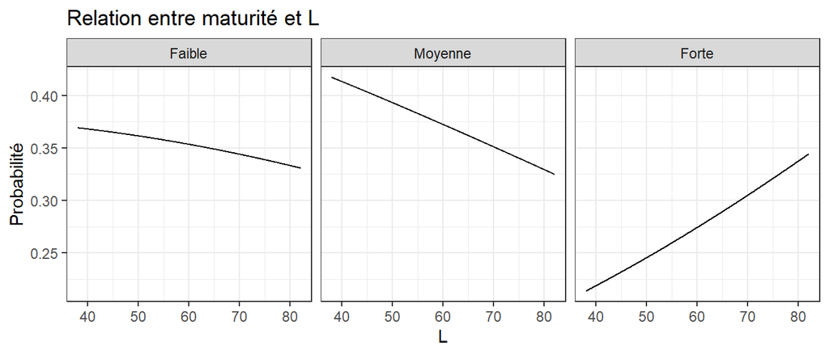

```r
probas <- probas %>% gather(Maturite,Proba,1:3) %>%
  mutate(Maturite=factor(Maturite,c("Faible","Moyenne","Forte")))
probas %>% ggplot(aes(x=L,y=Proba)) + geom_line() + ylab("Probabilité") +
  facet_grid(.~Maturite) + ggtitle("Relation entre maturité et L") + theme_bw()
```

## Effet sur la probabilité d’appartenir à un groupe

**Test d’analyse de la déviance**

```r
mod0 = multinom(Maturite~1,data=fruit,trace=FALSE)
mod1 = multinom(Maturite~L,data=fruit,trace=FALSE)
anova(mod0,mod1,test="Chisq") %>% kbl() %>%
  kable_paper(bootstrap_options = "striped", full_width = F)
```

| Model | Resid. df | Resid. Dev | Test | Df | LR stat. | Pr(Chi) |
| --- | --- | --- | --- | --- | --- | --- |
| 1 | 868 | 953 |  |  |  |  |
| L | 866 | 951 | 1 vs 2 | 2 | 1.2 | 0.549 |

**Conclusion : l’effet de la clarté sur la maturité n’est pas significatif au seuil de 5%**